# Final

## Y) MISSING DATA

```r
laptop_data_NA <- laptop_data
```

```r
# Specify observations to delete
remove_rate <- round(nrow(laptop_data_NA) *0.10)
remove_data <- sample(1:nrow(laptop_data_NA), remove_rate)

# Replace specified observations with NA
laptop_data_NA[remove_data, "Cpu_GHz"] <- NA
laptop_data_NA[remove_data, "Ram"] <- NA
```

Imputed Data

```r
laptop_data_imputed <- laptop_data
```

```r
# Specify observations to delete
remove_rate <- round(nrow(laptop_data_imputed) *0.10)
remove_data <- sample(1:nrow(laptop_data_imputed), remove_rate)

# Replace specified observations with NA
laptop_data_imputed[remove_data, "Cpu_GHz"] <- NA
laptop_data_imputed[remove_data, "Ram"] <- NA
```

```r
# Analyze missing values
imputed <- skim(laptop_data_imputed)
imputed[,1:19]
```

Data summary

| Name | laptop_data_imputed |
| --- | --- |
| Number of rows | 1303 |
| Number of columns | 19 |
| _______________________ |  |
| Column type frequency: |  |
| character | 3 |
| factor | 7 |
| numeric | 9 |
| ________________________ |  |
| Group variables | None |

**Variable type: character**

| skim_variable | n_missing | complete_rate | min | max | empty | n_unique | whitespace |
| --- | --- | --- | --- | --- | --- | --- | --- |
| ScreenResolution | 0 | 1 | 8 | 45 | 0 | 40 | 0 |
| Gpu | 0 | 1 | 13 | 30 | 0 | 110 | 0 |
| Cpu_Type | 0 | 1 | 12 | 34 | 0 | 96 | 0 |

**Variable type: factor**

| skim_variable | n_missing | complete_rate | ordered | n_unique | top_counts |
| --- | --- | --- | --- | --- | --- |
| Company | 0 | 1 | FALSE | 19 | Del: 297, Len: 297, HP: 274, Asu: 158 |
| TypeName | 0 | 1 | FALSE | 6 | Not: 727, Gam: 205, Ult: 196, 2 i: 121 |
| OpSys | 0 | 1 | FALSE | 9 | Win: 1072, No : 66, Lin: 62, Win: 45 |
| Memory_Type | 0 | 1 | FALSE | 17 | SSD: 623, 1TB: 223, SSD: 181, HDD: 134 |
| ScreenR_Type | 0 | 1 | FALSE | 21 | Ful: 507, emp: 314, IPS: 235, IPS: 53 |
| GpuInfo | 0 | 1 | FALSE | 4 | Int: 722, Nvi: 400, AMD: 180, ARM: 1 |
| CpuInfo | 0 | 1 | FALSE | 3 | Int: 1240, AMD: 62, Sam: 1 |

**Variable type: numeric**

| skim_variable | n_missing | complete_rate | mean | sd | p0 | p25 | p50 | p75 | p100 |
| --- | --- | --- | --- | --- | --- | --- | --- | --- | --- |
| Inches | 0 | 1.0 | 15.02 | 1.43 | 10.10 | 14.00 | 15.60 | 15.60 | 18.4 |
| Ram | 130 | 0.9 | 8.37 | 5.09 | 2.00 | 4.00 | 8.00 | 8.00 | 64.0 |
| Weight | 0 | 1.0 | 2.04 | 0.67 | 0.69 | 1.50 | 2.04 | 2.30 | 4.7 |
| Price | 0 | 1.0 | 59870.04 | 37243.20 | 9270.72 | 31914.72 | 52054.56 | 79274.25 | 324954.7 |
| Memory_GB | 0 | 1.0 | 2149.17 | 24577.78 | 1.00 | 64.00 | 256.00 | 504.00 | 512512.0 |
| Cpu_GHz | 130 | 0.9 | 2.30 | 0.50 | 0.90 | 2.00 | 2.50 | 2.70 | 3.6 |
| ScreenR_X | 0 | 1.0 | 1894.78 | 494.64 | 1366.00 | 1600.00 | 1920.00 | 1920.00 | 3840.0 |
| ScreenR_Y | 0 | 1.0 | 1070.83 | 284.52 | 768.00 | 900.00 | 1080.00 | 1080.00 | 2160.0 |
| Priciness | 0 | 1.0 | 0.41 | 0.49 | 0.00 | 0.00 | 0.00 | 1.00 | 1.0 |

```r
# Impute missing values
missingdata_model <- preProcess(laptop_data_imputed, method='knnImpute')
missingdata_model
```

```
## Created from 1173 samples and 19 variables
##
## Pre-processing:
##   - centered (9)
##   - ignored (10)
##   - 5 nearest neighbor imputation (9)
##   - scaled (9)
```

```r
laptop_data_imputed <- predict(missingdata_model, newdata = laptop_data_imputed)
anyNA(laptop_data_imputed)
```

```
## [1] FALSE
```

```r
# Take average of categorical column
missing_mean_price <- mean(laptop_data_imputed$Price)

# Identify values that are higher or lower than average
laptop_data_imputed$Priciness <- ifelse(laptop_data_imputed$Price < missing_mean_price, "0", "1")
```

Y.8.1 Random Forest Algorithm with NA Data

```r
# Set random seed for reproducibility
set.seed(123)
# Convert Priciness to factor
laptop_data_NA$Priciness <- as.factor(laptop_data_NA$Priciness)
# Create imbalanced stratified sample
sample_NA <- sample(2,nrow(laptop_data_NA),replace=T,prob = c(0.8,0.2))
# Split data into training and test sets
train_NA<-laptop_data_NA[sample_NA==1,]
test_NA<-laptop_data_NA[sample_NA==2,]
```

1. Use appropriate functions and arguments,

```r
train_drop_NA <- drop_na(train_NA)
# Build random forest model with proximity
NA_rf_model <- randomForest(Priciness~., data=train_drop_NA, proximity=TRUE)
NA_rf_model
```

```
##
## Call:
##  randomForest(formula = Priciness ~ ., data = train_drop_NA, proximity = TRUE)
##                Type of random forest: classification
##                      Number of trees: 500
## No. of variables tried at each split: 4
##
##         OOB estimate of  error rate: 0.11%
## Confusion matrix:
##     0   1 class.error
## 0 547   0 0.000000000
## 1   1 396 0.002518892
```

```r
test_drop_NA <- drop_na(test_NA)
# Predict Priciness on test data
predicted_rf <- predict(NA_rf_model, test_drop_NA)
confusionMatrix(predicted_rf, test_drop_NA$Priciness)
```

```
## Confusion Matrix and Statistics
##
##           Reference
## Prediction   0   1
##          0 141   0
##          1   0  88
##
##                Accuracy : 1
##                  95% CI : (0.984, 1)
##     No Information Rate : 0.6157
##     P-Value [Acc > NIR] : < 2.2e-16
##
##                   Kappa : 1
##
##  Mcnemar's Test P-Value : NA
##
##             Sensitivity : 1.0000
##             Specificity : 1.0000
##          Pos Pred Value : 1.0000
##          Neg Pred Value : 1.0000
##              Prevalence : 0.6157
##          Detection Rate : 0.6157
##    Detection Prevalence : 0.6157
##       Balanced Accuracy : 1.0000
##
##        'Positive' Class : 0
##
```

2. Use visualization techniques. Describe the result!

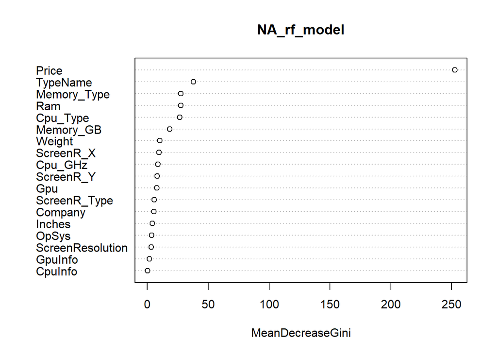

```r
varImpPlot(NA_rf_model)
```

c. Make your final comments clearly. The codes I applied on data containing NA values gave an error. When I used the drop_na function, the accuracy value was 1.

Y.8.1 Random Forest Algorithm with Imputed Data

```r
# Set random seed for reproducibility
set.seed(123)
# Convert Priciness to factor
laptop_data_imputed$Priciness <- as.factor(laptop_data_imputed$Priciness)
# Create imbalanced stratified sample
sample_imputed <- sample(2,nrow(laptop_data_imputed),replace=T,prob = c(0.8,0.2))
# Split data into training and test sets
train_imputed<-laptop_data_imputed[sample_imputed==1,]
test_imputed<-laptop_data_imputed[sample_imputed==2,]
```

1. Use appropriate functions and arguments,

```r
# Build random forest model with proximity
missing_rf_model <- randomForest(Priciness~., data=train_imputed, proximity=TRUE)
missing_rf_model
```

```
##
## Call:
##  randomForest(formula = Priciness ~ ., data = train_imputed, proximity = TRUE)
##                Type of random forest: classification
##                      Number of trees: 500
## No. of variables tried at each split: 4
##
##         OOB estimate of  error rate: 0.1%
## Confusion matrix:
##     0   1 class.error
## 0 611   0 0.000000000
## 1   1 438 0.002277904
```

```r
# Predict Priciness on test data
predicted_rf <- predict(missing_rf_model, test_imputed)
confusionMatrix(predicted_rf, test_imputed$Priciness)
```

```
## Confusion Matrix and Statistics
##
##           Reference
## Prediction   0   1
##          0 156   1
##          1   0  96
##
##                Accuracy : 0.996
##                  95% CI : (0.9782, 0.9999)
##     No Information Rate : 0.6166
##     P-Value [Acc > NIR] : <2e-16
##
##                   Kappa : 0.9916
##
##  Mcnemar's Test P-Value : 1
##
##             Sensitivity : 1.0000
##             Specificity : 0.9897
##          Pos Pred Value : 0.9936
##          Neg Pred Value : 1.0000
##              Prevalence : 0.6166
##          Detection Rate : 0.6166
##    Detection Prevalence : 0.6206
##       Balanced Accuracy : 0.9948
##
##        'Positive' Class : 0
##
```

2. Use visualization techniques. Describe the result!

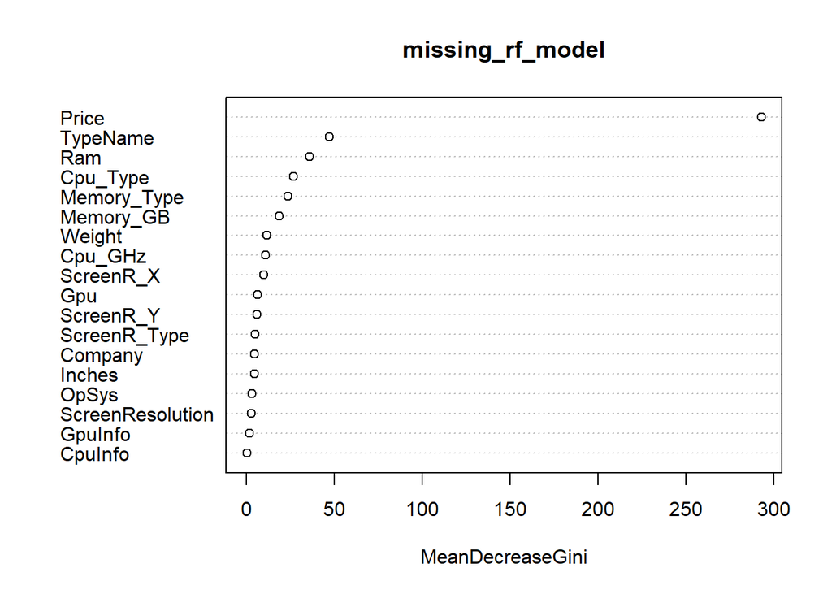

```r
varImpPlot(missing_rf_model)
```

Compare the “results with missing values” and “result with imputed values”. (DON’T compare it with the original dataset!). Which performance scores you chose? What is your final decision? If we compare the accuracy rates, results with missing values have a better accuracy rate. But I think result with imputed values was a more purposeful approach. Because the other one didn’t work without filling in the gaps.

## 9) Hyperparameter Tuning, with all your explanation and comments

```r
library(randomForest)
# Define the target variable
y <- train_imbalance$Priciness

# Define the hyperparameter space
hyper_parameters <- expand.grid(
  n_estimators = c(100, 200),
  max_depth = c(5, 10),
  min_samples_split = c(5, 10),
  min_samples_leaf = c(5, 10),
  mtry = c(2, 3)
)

# Perform the grid search
results <- list()
predictions <- list()
matricies <- list()
for (i in 1:nrow(hyper_parameters)) {
  model <- randomForest(y ~ ., data = train_imbalance, ntree = hyper_parameters$n_estimators[i], maxdepth = hyper_parameters$max_depth[i], min_samples_split = hyper_parameters$min_samples_split[i], min_samples_leaf = hyper_parameters$min_samples_leaf[i], mtry = hyper_parameters$mtry[i])
  results[[i]] <- model
  predictions[[i]] <-predict(model, test_imbalance)
  predicted_rf <- predict(model, test_imbalance)
  matricies[[i]] <- confusionMatrix(predicted_rf, test_imbalance$Priciness)
}
```

```r
print(matricies)
```

```
## [[1]]
## Confusion Matrix and Statistics
##
##           Reference
## Prediction   0   1
##          0 156   0
##          1   0  97
##
##                Accuracy : 1
##                  95% CI : (0.9855, 1)
##     No Information Rate : 0.6166
##     P-Value [Acc > NIR] : < 2.2e-16
##
##                   Kappa : 1
##
##  Mcnemar's Test P-Value : NA
##
##             Sensitivity : 1.0000
##             Specificity : 1.0000
##          Pos Pred Value : 1.0000
##          Neg Pred Value : 1.0000
##              Prevalence : 0.6166
##          Detection Rate : 0.6166
##    Detection Prevalence : 0.6166
##       Balanced Accuracy : 1.0000
##
##        'Positive' Class : 0
##
##
## [[2]]
## Confusion Matrix and Statistics
##
##           Reference
## Prediction   0   1
##          0 156   0
##          1   0  97
##
##                Accuracy : 1
##                  95% CI : (0.9855, 1)
##     No Information Rate : 0.6166
```

[output cut: 872 more lines]

```
##                   Kappa : 1
##
##  Mcnemar's Test P-Value : NA
##
##             Sensitivity : 1.0000
##             Specificity : 1.0000
##          Pos Pred Value : 1.0000
##          Neg Pred Value : 1.0000
##              Prevalence : 0.6166
##          Detection Rate : 0.6166
##    Detection Prevalence : 0.6166
##       Balanced Accuracy : 1.0000
##
##        'Positive' Class : 0
##
```

Seems to perform well on many models

## 10) Cross- Validation, with all your explanation and comments

Imbalance Data

```r
laptop_data_with_ıd <- read.csv("C:/Users/monster/Desktop/laptop_data.csv")
head(laptop_data_with_ıd)
```

```
##   X Company  TypeName Inches                   ScreenResolution
## 1 0   Apple Ultrabook   13.3 IPS Panel Retina Display 2560x1600
## 2 1   Apple Ultrabook   13.3                           1440x900
## 3 2      HP  Notebook   15.6                  Full HD 1920x1080
## 4 3   Apple Ultrabook   15.4 IPS Panel Retina Display 2880x1800
## 5 4   Apple Ultrabook   13.3 IPS Panel Retina Display 2560x1600
## 6 5    Acer  Notebook   15.6                           1366x768
##                          Cpu  Ram              Memory
## 1       Intel Core i5 2.3GHz  8GB           128GB SSD
## 2       Intel Core i5 1.8GHz  8GB 128GB Flash Storage
## 3 Intel Core i5 7200U 2.5GHz  8GB           256GB SSD
## 4       Intel Core i7 2.7GHz 16GB           512GB SSD
## 5       Intel Core i5 3.1GHz  8GB           256GB SSD
## 6    AMD A9-Series 9420 3GHz  4GB           500GB HDD
##                            Gpu      OpSys Weight     Price
## 1 Intel Iris Plus Graphics 640      macOS 1.37kg  71378.68
## 2       Intel HD Graphics 6000      macOS 1.34kg  47895.52
## 3        Intel HD Graphics 620      No OS 1.86kg  30636.00
## 4           AMD Radeon Pro 455      macOS 1.83kg 135195.34
## 5 Intel Iris Plus Graphics 650      macOS 1.37kg  96095.81
## 6                AMD Radeon R5 Windows 10  2.1kg  21312.00
```

```r
numerical_columns$X <-laptop_data_with_ıd$X
```

```r
#specify the cross-validation method
ctrl <- trainControl(method = "cv", number = 5)

#fit a regression model and use k-fold CV to evaluate performance
model <- train(X~ ., data = numerical_columns, method = "lm", trControl = ctrl)
print(model)
```

```
## Linear Regression
##
## 1303 samples
##    9 predictor
##
## No pre-processing
## Resampling: Cross-Validated (5 fold)
## Summary of sample sizes: 1043, 1041, 1043, 1043, 1042
## Resampling results:
##
##   RMSE     Rsquared    MAE
##   364.281  0.06507783  310.5981
##
## Tuning parameter 'intercept' was held constant at a value of TRUE
```

```r
model$finalModel
```

```
##
## Call:
## lm(formula = .outcome ~ ., data = dat)
##
## Coefficients:
## (Intercept)       Inches          Ram       Weight        Price    Memory_GB
##   1.493e+03   -7.440e+01   -1.281e+01    1.119e+02    1.058e-03   -4.267e-04
##     Cpu_GHz    ScreenR_X    ScreenR_Y    Priciness
##   8.432e+01    8.407e-01   -1.613e+00    8.007e+01
```

```r
#We can use the following code to view the model predictions made for each fold
model$resample
```

```
##       RMSE   Rsquared      MAE Resample
## 1 362.1237 0.05739946 307.7905    Fold1
## 2 367.0803 0.06974945 312.0192    Fold2
## 3 359.9667 0.08129965 305.6182    Fold3
## 4 362.4590 0.07727505 312.2681    Fold4
## 5 369.7751 0.03966554 315.2943    Fold5
```

Balance Data

```r
# Create a new data frame with balanced data
balance_Id_numeric_under <- ovun.sample(Priciness ~ ., data = numerical_columns, method = "under", N = 1072, seed = 1)$data
```

```r
#specify the cross-validation method
ctrl2 <- trainControl(method = "cv", number = 5)

#fit a regression model and use k-fold CV to evaluate performance
model2 <- train(X ~ ., data = balance_Id_numeric_under, method = "lm", trControl = ctrl)
print(model2)
```

```
## Linear Regression
##
## 1072 samples
##    9 predictor
##
## No pre-processing
## Resampling: Cross-Validated (5 fold)
## Summary of sample sizes: 859, 857, 857, 857, 858
## Resampling results:
##
##   RMSE      Rsquared    MAE
##   356.3996  0.07542357  301.9157
##
## Tuning parameter 'intercept' was held constant at a value of TRUE
```

```r
model2$finalModel
```

```
##
## Call:
## lm(formula = .outcome ~ ., data = dat)
##
## Coefficients:
## (Intercept)       Inches          Ram       Weight        Price    Memory_GB
##   1.741e+03   -9.072e+01   -9.428e+00    1.161e+02    9.837e-04   -4.305e-04
##     Cpu_GHz    ScreenR_X    ScreenR_Y    Priciness
##   6.876e+01    8.534e-01   -1.617e+00    5.004e+01
```

```r
#We can use the following code to view the model predictions made for each fold
model2$resample
```

```
##       RMSE   Rsquared      MAE Resample
## 1 350.7981 0.08058180 297.9086    Fold1
## 2 353.4289 0.11994041 296.6743    Fold2
## 3 353.0408 0.11404948 302.1509    Fold3
## 4 356.2280 0.03116988 300.6128    Fold4
## 5 368.5020 0.03137628 312.2322    Fold5
```